# Human Activity: Machine Learning

Johannes Tynes

May 8th 2017

# Summary

This is a machine learning modeling exercised aimed at developing a predictive ML model for human activity identification.

The data used by the model encompasses over 19k training examples with physical characteristics of a training exercise, as well as data on 5 different ways in which the exercise can be done.

The purpose of the model was to predict in which of the 5 ways the exercise was done.

A gradient boosting machine was developd for classification based on data with near-zero variability variables omitted along with variables with a significant missing-data percentage. The model was developed using 4-fold randomly sampled cross validation and achieved an accuracy of around 98.2%.

## Loading Data

```r
# Data is read from CSV files using `readr::read_csv`:
read <- function(fp) {
  read_csv(fp) %>%
  mutate_each_(funs(factor),
    vars=intersect(colnames(.), c("user_name", "new_window", "classe"))) %>%
  mutate_if("is.character", "as.numeric") %>%
  select(-1)
}

# Loading the training and testing data into `d` variable:
  list(test="pml-testing.csv", train="pml-training.csv") %>%
  llply(read) ->
d
```

### Data PreProcessing

The first step taken in data pre-processing has been to eliminate potential explanatory variables with very low variability and consequently limited potential to add predictive value to the model.

In order to identify near-zero-variability variables the `caret::nearZeroVar` function was used:

```r
d[["train"]] %<>% {.[,-nearZeroVar(.)]}
```

As a second step in data pre-processing was investigating whether there were any variables with large numbers of missing values. The figure below shows that the distribution of missing value percentages across variables.

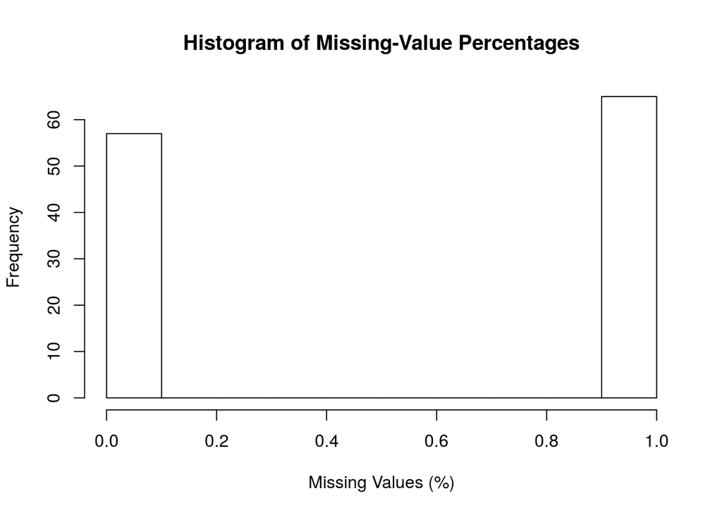

```r
d[["train"]] %>% apply(2, . %>% is.na %>% mean) %>%
hist(main="Histogram of Missing-Value Percentages", xlab="Missing Values (%)")
```

Based on this it can be seen that: * A majority of variables suffer from a very high missing-values percentage. * Nearly half of the variables have very few missing value.

> It was decided to omit variables with over 30% missing values.

```r
d[["train"]] %<>% (function(i) {
  i[, apply(i, 2, . %>% is.na %>% mean) %>% `<=`(.3)]})
```

As a final pre-processing step, variables with unlikely predictive power were omitted (user-name, time stamps):

```r
d[["train"]] %<>% select(-user_name, -matches("_timestamp_"))
```

### Training the Predictive Model

The predictive model was fitted and assessed using a gradient boosting machine because it is a versatile algorithm for classification that can fit a wide range of classification problems and, in the author’s experience, is usually at least comparable in performance terms to tuned random forest and support vector machine implementations.

```r
# Setting seed for reproducibility:
set.seed(1)
# Training the model
  train(
    classe ~ .,
    data=d[["train"]] %>% sample_n(10000),
    method="gbm",
    trControl=trainControl(method="cv", number=4),
    verbose=FALSE,
    na.action=na.pass) ->
m
```

The model was trained: * using the `caret::train` function as a wrapper around `gbm`. * with validation through a 4-fold cross validation on 10k-observation samples (for reasons of computational speed)

## Model Performance

The tuned GBM model has an achieved accuracy of 0.9823995 using an interaction depth of 3 and 150 trees.

## Applying the Model to Predict Test Cases

```r
p <- predict(m, newdata=d[["test"]])
write.csv(cbind(d[["test"]], classe=p), file="ml_predictions.csv")
```